# Report of MA615 Final Assignment

Zhe Yu

2020/12/14

## Data Collection

I use two ways to collect data: (a)use API key and `Jsonlite` package to download job data from [Adzuna](https://www.adzuna.com.au/); (b)use `rvest` package to capture data from source code of [Indeed](https://nz.indeed.com/).

```r
#(a) using API
gb <- data.frame()#create a blank data frame
for(i in 1:100){
  file <- jsonlite::fromJSON(paste0("https://api.adzuna.com/v1/api/jobs/gb/search/",i,"?app_id=f0c87e31&app_key=84f049d50dd8aa26e2e48aff8ba0e61f&results_per_page=50&what_or=data%20scientist%20statistician"))
  df_new <- file$results
  gb <- bind_rows(gb,df_new)
}# using loop to download data in different pages
#cause the description is only a summary so I also use rvest to get the full information
for (i in (1:length(gb$redirect_url))){
  detail <- tryCatch(
    html_text(html_node(read_html(as.character(gb$redirect_url[i])),'.job_details_body')),
    error=function(e){NA}
  )
  if (is.null(detail)){
    desc <- NA
  }
  gb$detail[i] <- detail
}

#(b)using rvest
listings <- data.frame(title=character(),
                       company=character(),
                       location=character(),
                       summary=character(),
                       link=character(),
                       description = character(),
                       stringsAsFactors=FALSE) #create empty data frame
for (i in seq(0, 1000, 10)){
  url_ds <- paste0('https://www.indeed.com/jobs?q=data+scientist&l=all&start=',i)
  var <- read_html(url_ds)


  #job title
  title <-  var %>%
    html_nodes('#resultsCol .jobtitle') %>%
    html_text() %>%
    str_extract("(\\w+.+)+")

  #company
  company <- var %>%
    html_nodes('#resultsCol .company') %>%
    html_text() %>%
    str_extract("(\\w+).+")

  #location
  location <- var %>%
    html_nodes('#resultsCol .location') %>%
    html_text() %>%
    str_extract("(\\w+.)+,.[A-Z]{2}")
  #summary
  summary <- var %>%
    html_nodes('#resultsCol .summary') %>%
    html_text() %>%
    str_extract(".+")

  #link
  link <- var %>%
    html_nodes('#resultsCol .jobtitle .turnstileLink, #resultsCol a.jobtitle') %>%
    html_attr('href')
  link <- paste0("https://www.indeed.com",link)

  listings <- rbind(listings, as.data.frame(cbind(title,
                                                  company,
                                                  location,
                                                  summary,
                                                  link)))
}
for (i in (1:length(listings$link))){
  desciption <- tryCatch(
    html_text(html_node(read_html(as.character(listings$link[i])),'.jobsearch-JobComponent-description')),
    error=function(e){NA}
  )
  if (is.null(desciption)){
    desc <- NA
  }
  listings$description[i] <- desciption
}
```

## Data Cleaning

I filter out rows without longitude and latitude and without salary information And than select the vaiables that is useful. Since area information is contained in vectors so I use `separate` function to clean them into for columns: Country, State, County and city. Also in description and title there are some HTML tags, I use `str_replace_all` to replace them.

```r
full %<>% filter(is.na(longitude)==F) %<>% filter(is.na(latitude)==F)
With_salary <- full %>% filter(is.na(salary_max)==F) %<>% filter(is.na(salary_min)==F)

full %<>% select(c("id","title","description","tag","label","area","location_name","latitude","longitude","salary_min","salary_max"))

# clean area
clean_1 <- full  %>% separate(area,into = c("country","state","county","city"),sep=",")
clean_1 %<>% separate(country,into = c("de1","country","de2"),sep = '"')
clean_1 %<>% separate(state,into = c("de3","state","de4"),sep = '"')
clean_1 %<>% separate(county,into = c("de5","county","de6"),sep = '"')
clean_1 %<>% separate(city,into = c("de5","city","de6"),sep = '"')
clean_1 %<>% select(-c("de1","de2","de3","de4","de5","de6"))

# clean title and description
clean_1$title <- str_replace_all(clean_1$title, "<strong>","")
clean_1$title <- str_replace_all(clean_1$title, "</strong>","")
clean_1$description <- str_replace_all(clean_1$description, "<strong>","")
clean_1$description <- str_replace_all(clean_1$description, "</strong>","")
```

To make sure that all the information in data frame is UTF-8 encoding.

```r
Encoding(clean_gb$description) <- "UTF-8"
clean_gb$description <- iconv(x=clean_gb$description,from = "UTF-8",to = "UTF-8",sub = "")
Encoding(clean_gb$title) <- "UTF-8"
clean_gb$title <- iconv(x=clean_gb$title,from = "UTF-8",to = "UTF-8",sub = "")
Encoding(clean_gb$detail) <- "UTF-8"
clean_gb$detail <- iconv(x=clean_gb$detail,from = "UTF-8",to = "UTF-8",sub = "")
```

## Mapping

In Adzuna data, there are longitudes and latitudes indicate the specific location of workplace, so I use `Leaflet` to draw them on the maps. Circles with gather together if you narrow the map. And if can show more information if you can enlarge the map and click those circles. And also, I show the salary information in this map, the deep the color, the higher the salary.(Since only jobs in UK shows the salary information, so I will focus on UK in this assignment.)

[interactive chart not shown]

## Text Mining

### Adzuna vs Indeed

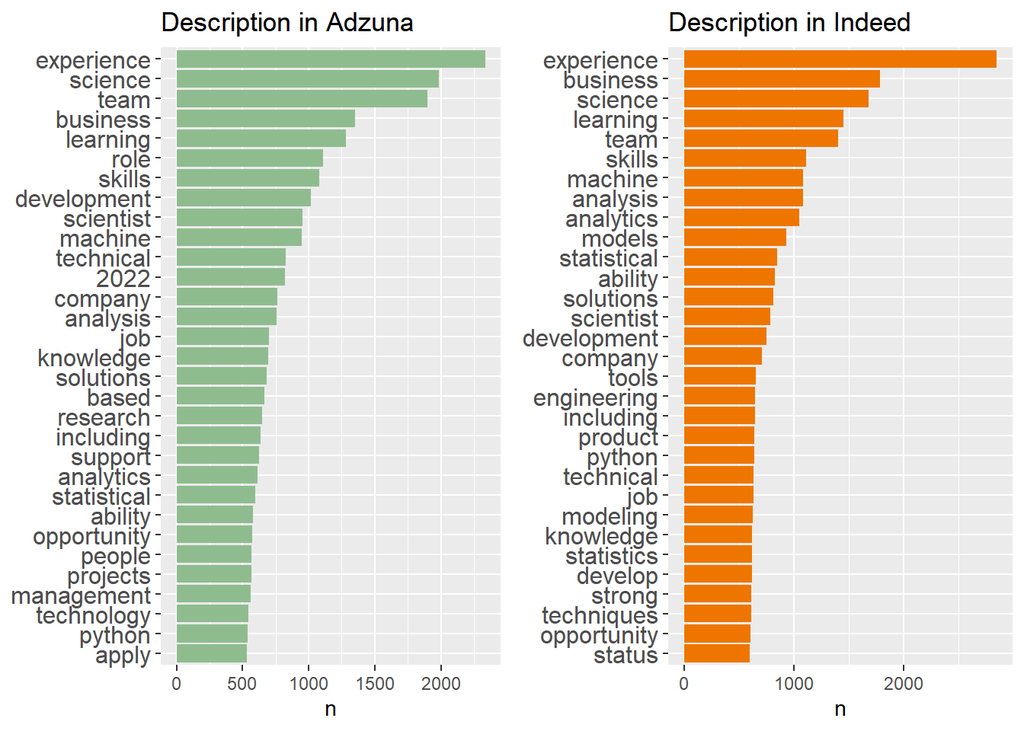

```
## # A tibble: 15,989 x 2
##    word            n
##    <chr>       <int>
##  1 data         6128
##  2 experience   2334
##  3 science      1982
##  4 team         1899
##  5 business     1351
##  6 learning     1279
##  7 role         1110
##  8 skills       1082
##  9 development  1018
## 10 scientist     951
## # ... with 15,979 more rows
```

```
## # A tibble: 11,700 x 2
##    word           n
##    <chr>      <int>
##  1 data        6889
##  2 experience  2851
##  3 business    1783
##  4 science     1682
##  5 learning    1452
##  6 team        1402
##  7 skills      1110
##  8 machine     1087
##  9 analysis    1082
## 10 analytics   1053
## # ... with 11,690 more rows
```

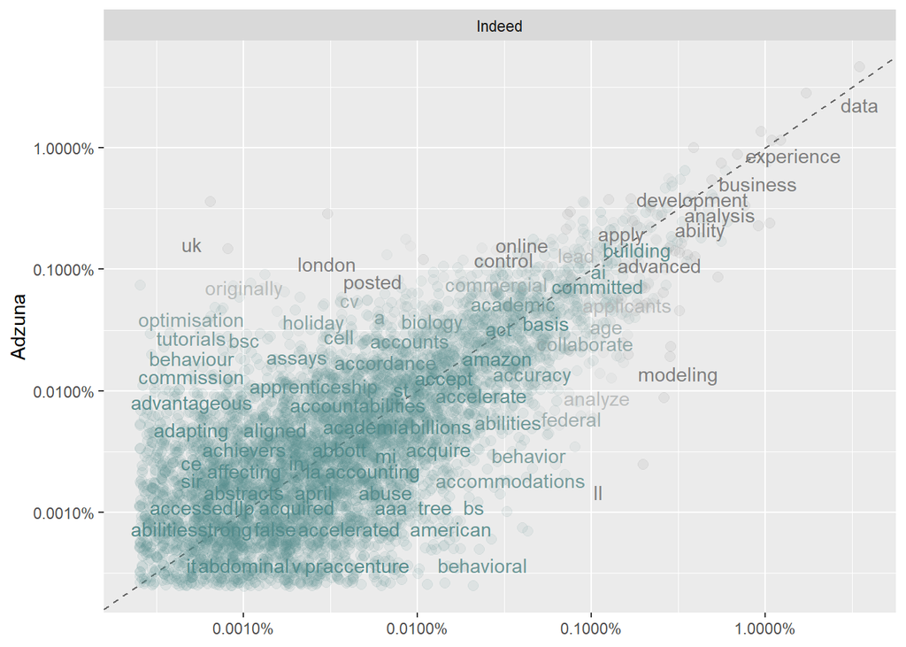

Comparing the count of words in two website, they are almost the same. Words like ‘experience’, ‘team’, ‘skills’ are all have high frequency in both two websites. And we can see that python and machine learning are always mentioned so they are really important skills. In frequency plot, in Adzuna, ‘UK’ and ‘London’ are frequently mentioned cause jobs in that data is all from UK, so it makes sense. And also ‘modeling’ is mentioned more in Indeed.

### Job Description in different salary level

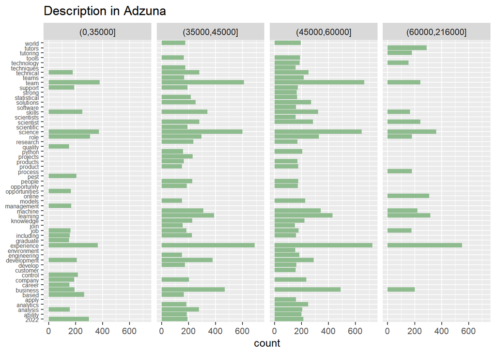

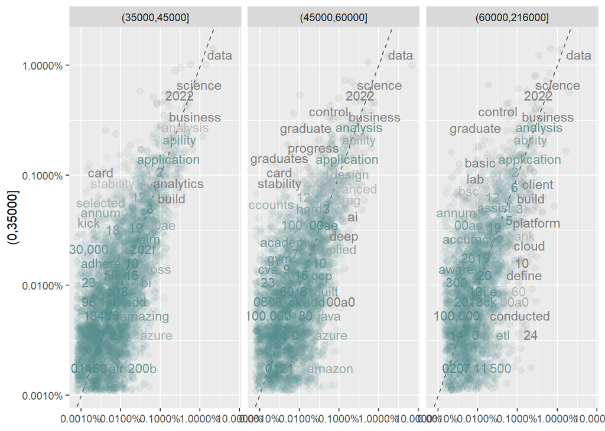

It is clear that in different level of salary, the distribution of words are almost the same but in some group there are some words not mentioned, it may because the number of jobs is small in that group. But also may because they are not important in that level. In frequency plot, it looks almost the same for each level. But it is obvious that ‘graduates’ are mentioned more in level (0,35000].

### Job Description in different location

```
## # A tibble: 35,592 x 3
## # Groups:   state [12]
##    state         word    count
##    <chr>         <chr>   <int>
##  1 East Midlands 0           1
##  2 East Midlands 01256       1
##  3 East Midlands 1           5
##  4 East Midlands 10          4
##  5 East Midlands 100         1
##  6 East Midlands 11,000      1
##  7 East Midlands 12          6
##  8 East Midlands 125         1
##  9 East Midlands 12month     2
## 10 East Midlands 15          1
## # ... with 35,582 more rows
```

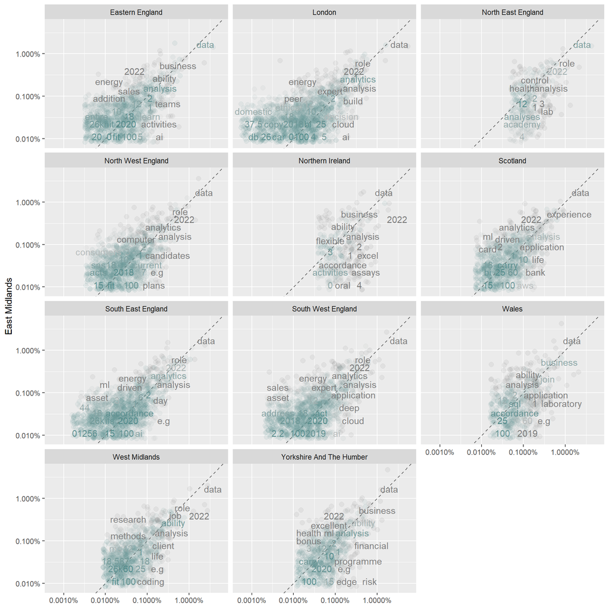

It is hard to have some conclusion from this plot, but London is obviously different cause majority of jobs are in London; And in Yorkshire And The Humber, ‘financial’ is mentioned more than it in East Midlands.